# Introduction to R demos

Counting, grouping, and summarizing

Dr. Joseph P. Yurko

## Overview

This report reviews how to count, group, and summarize data with the `tidyverse`. We will use simple data sets which are available within base `R` and `tidyverse`. I will use the forward pipe operator `%>%` throughout this report.

## Load packages

The code chunk below loads in the packages we will use. Just a single library is loaded in, `tidyverse`, which brings in multiple packages as shown in the code chunk display below.

```r
library(tidyverse)
```

## Counting with `iris`

The `iris` data set is pre-loaded by base `R`. So let’s get an idea about the structure with the `glimpse()` function.

```r
iris %>% glimpse()
```

```
## Rows: 150
## Columns: 5
## $ Sepal.Length <dbl> 5.1, 4.9, 4.7, 4.6, 5.0, 5.4, 4.6, 5.0, 4.4, 4.9, 5.4, 4.…
## $ Sepal.Width  <dbl> 3.5, 3.0, 3.2, 3.1, 3.6, 3.9, 3.4, 3.4, 2.9, 3.1, 3.7, 3.…
## $ Petal.Length <dbl> 1.4, 1.4, 1.3, 1.5, 1.4, 1.7, 1.4, 1.5, 1.4, 1.5, 1.5, 1.…
## $ Petal.Width  <dbl> 0.2, 0.2, 0.2, 0.2, 0.2, 0.4, 0.3, 0.2, 0.2, 0.1, 0.2, 0.…
## $ Species      <fct> setosa, setosa, setosa, setosa, setosa, setosa, setosa, s…
```

We can also get a high level summary of the different variables in `iris` with the `summary()` function.

```r
iris %>% summary()
```

```
##   Sepal.Length    Sepal.Width     Petal.Length    Petal.Width
##  Min.   :4.300   Min.   :2.000   Min.   :1.000   Min.   :0.100
##  1st Qu.:5.100   1st Qu.:2.800   1st Qu.:1.600   1st Qu.:0.300
##  Median :5.800   Median :3.000   Median :4.350   Median :1.300
##  Mean   :5.843   Mean   :3.057   Mean   :3.758   Mean   :1.199
##  3rd Qu.:6.400   3rd Qu.:3.300   3rd Qu.:5.100   3rd Qu.:1.800
##  Max.   :7.900   Max.   :4.400   Max.   :6.900   Max.   :2.500
##        Species
##  setosa    :50
##  versicolor:50
##  virginica :50
##
##
##
```

As we can see, the `Species` variable is a `factor` which is `R`’s terminology for categorical or discrete variables. The `summary()` function shows us that there are 3 unique values, called **levels** in `R`. Those three levels correspond to three different species of the flowers.

We can determine the number of observations or rows for each unique value several ways besides just using the `summary()` function. I particularly like the `count()` function from `dplyr` (which was loaded in through the `tidyverse` library). The arguments to `count()` is the variable we wish to, as the function name states, count. `count()` will then “count up” the number of observations (rows) associated with each unique value of a variable. Let’s see how this works with the `Species` variable.

```r
iris %>%
  count(Species)
```

```
##      Species  n
## 1     setosa 50
## 2 versicolor 50
## 3  virginica 50
```

As we can see above, the output of `count()` has 2 columns. The first column is the variable we wanted to count with rows associated with each unique value. The second column, `n`, is a column created by `count()`. It is the number of observations (rows) associated with each unique value. For `iris` we see that there are 50 observations associated with each level.

## Counting with `starwars`

The `dplyr` package includes a data set associated with characters from Star Wars movies. A glimpse is provided below.

```r
starwars %>% glimpse()
```

```
## Rows: 87
## Columns: 14
## $ name       <chr> "Luke Skywalker", "C-3PO", "R2-D2", "Darth Vader", "Leia Or…
## $ height     <int> 172, 167, 96, 202, 150, 178, 165, 97, 183, 182, 188, 180, 2…
## $ mass       <dbl> 77.0, 75.0, 32.0, 136.0, 49.0, 120.0, 75.0, 32.0, 84.0, 77.…
## $ hair_color <chr> "blond", NA, NA, "none", "brown", "brown, grey", "brown", N…
## $ skin_color <chr> "fair", "gold", "white, blue", "white", "light", "light", "…
## $ eye_color  <chr> "blue", "yellow", "red", "yellow", "brown", "blue", "blue",…
## $ birth_year <dbl> 19.0, 112.0, 33.0, 41.9, 19.0, 52.0, 47.0, NA, 24.0, 57.0, …
## $ sex        <chr> "male", "none", "none", "male", "female", "male", "female",…
## $ gender     <chr> "masculine", "masculine", "masculine", "masculine", "femini…
## $ homeworld  <chr> "Tatooine", "Tatooine", "Naboo", "Tatooine", "Alderaan", "T…
## $ species    <chr> "Human", "Droid", "Droid", "Human", "Human", "Human", "Huma…
## $ films      <list> <"The Empire Strikes Back", "Revenge of the Sith", "Return…
## $ vehicles   <list> <"Snowspeeder", "Imperial Speeder Bike">, <>, <>, <>, "Imp…
## $ starships  <list> <"X-wing", "Imperial shuttle">, <>, <>, "TIE Advanced x1",…
```

As we can see there are multiple data types, including character strings (denoted by the `<chr>`). We can check an individual variable in a tibble using the `$` operator and the `class()` function. So let’s check the data type associated with `eye_color`.

```r
class(starwars$eye_color)
```

```
## [1] "character"
```

Alternatively, we can check the data type using the `dplyr` verb `pull()` to “pull” or extract the `eye_color` column from `starwars` and the forward pipe operator to pass the vector to the `class()` function. Both approaches, the “traditional function” approach or the “forward pipe” approach, are valid. It is up to you which you prefer to use.

```r
starwars %>% pull(eye_color) %>% class()
```

```
## [1] "character"
```

We can use the `count()` function to count the unique values associated with any data type. So let’s see how many rows are associated with each unique value of the `eye_color` in the `starwars` data set.

```r
starwars %>% count(eye_color)
```

```
## # A tibble: 15 × 2
##    eye_color         n
##    <chr>         <int>
##  1 black            10
##  2 blue             19
##  3 blue-gray         1
##  4 brown            21
##  5 dark              1
##  6 gold              1
##  7 green, yellow     1
##  8 hazel             3
##  9 orange            8
## 10 pink              1
## 11 red               5
## 12 red, blue         1
## 13 unknown           3
## 14 white             1
## 15 yellow           11
```

As we can see some of the values have more rows than others. The order is listed in alphabetical order which makes it difficult to see which eye color is the most common in the data set. So let’s reorder the display with the `arrange()` function. The input argument to the `arrange()` function is the `n` variable which was created by `count()`.

```r
starwars %>% count(eye_color) %>%
  arrange(n)
```

```
## # A tibble: 15 × 2
##    eye_color         n
##    <chr>         <int>
##  1 blue-gray         1
##  2 dark              1
##  3 gold              1
##  4 green, yellow     1
##  5 pink              1
##  6 red, blue         1
##  7 white             1
##  8 hazel             3
##  9 unknown           3
## 10 red               5
## 11 orange            8
## 12 black            10
## 13 yellow           11
## 14 blue             19
## 15 brown            21
```

```r
starwars %>%
  count(eye_color) %>%
  arrange(desc(n))
```

```
## # A tibble: 15 × 2
##    eye_color         n
##    <chr>         <int>
##  1 brown            21
##  2 blue             19
##  3 yellow           11
##  4 black            10
##  5 orange            8
##  6 red               5
##  7 hazel             3
##  8 unknown           3
##  9 blue-gray         1
## 10 dark              1
## 11 gold              1
## 12 green, yellow     1
## 13 pink              1
## 14 red, blue         1
## 15 white             1
```

Displaying the result as a tibble within the RMarkdown directly is useful, but when rendering the document to HTML the displayed tibble may not look all that great. So let’s pipe the result to the `knitr::kable()` function which provides a “prettier” display of the table.

```r
starwars %>%
  count(eye_color) %>%
  arrange(desc(n)) %>%
  knitr::kable()
```

| eye_color | n |
| --- | --- |
| brown | 21 |
| blue | 19 |
| yellow | 11 |
| black | 10 |
| orange | 8 |
| red | 5 |
| hazel | 3 |
| unknown | 3 |
| blue-gray | 1 |
| dark | 1 |
| gold | 1 |
| green, yellow | 1 |
| pink | 1 |
| red, blue | 1 |
| white | 1 |

Counting of one variable is great, but `count()` is also capable of counting the number of observations associated with combinations of variables. All we have to do is pass in additional arguments to the `count()`. The code chunk below shows how we can count the number of rows associated with the combination of `eye_color` and `hair_color`. The display is then ordered by the number of observations in descending order.

```r
starwars %>%
  count(eye_color, hair_color) %>%
  arrange(desc(n))
```

```
## # A tibble: 35 × 3
##    eye_color hair_color     n
##    <chr>     <chr>      <int>
##  1 black     none           9
##  2 brown     black          9
##  3 brown     brown          9
##  4 blue      brown          7
##  5 orange    none           7
##  6 yellow    none           6
##  7 blue      blond          3
##  8 blue      none           3
##  9 red       none           3
## 10 blue      black          2
## # … with 25 more rows
```

When the number of combinations is large, it can be useful to visualize the counts with a heat map. We can pipe the result to `ggplot()` and use the `geom_tile()` geometric object to create a heat map. The code chunk below shows the steps necessary to create the heat map for the combinations of `eye_color` and `hair_color` by mapping the `n` variable to the `fill` aesthetic to `geom_tile()`. I also like to display the count as text using the `geom_text()` geom with the `n` variable mapped to the `label` aesthetic. The `theme()` function is used to make text associated the `eye_color` axis look easier to read by rotating the labels 90 degrees.

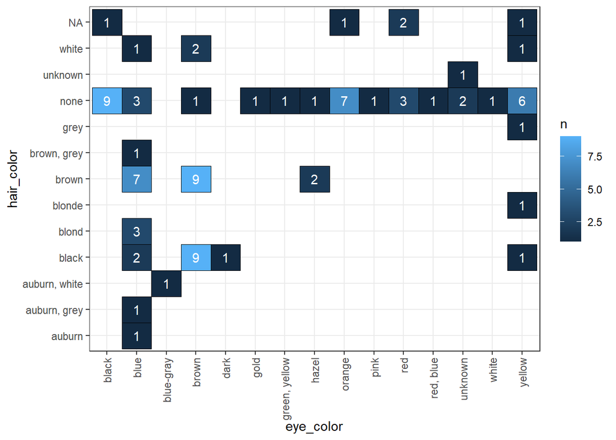

```r
starwars %>%
  count(eye_color, hair_color) %>%
  ggplot(mapping = aes(x = eye_color, y = hair_color)) +
  geom_tile(mapping = aes(fill = n), color = "black") +
  geom_text(mapping = aes(label = n), color = "white") +
  theme_bw() +
  theme(axis.text.x = element_text(angle=90, hjust = 1, vjust = 0.5))
```

Heat maps are particularly useful visualizations for showing combinations that do not appear in a data set. There is a lot of white space in the above heat map. White space (or blank space depending on the panel fill color) represents the combination was not observed. It does not mean an entry’s or record’s value was missing in the data. It means the combination of two specific values did not occur.

## Fractions and proportions

We can use the result of the `count()` function calculate the fraction or proportion of the rows. We can pipe the result `mutate()` and perform additional operations as we want. The code chunk below demonstrates how to calculate the proportion or fraction of the observations associated with each combination of eye and hair color. The `mutate()` function creates a new column `proportion_obs` which is equal to the `n` variable divided by the `sum(n)`.

```r
starwars %>%
  count(eye_color, hair_color) %>%
  arrange(desc(n)) %>%
  mutate(proportion_obs = n / sum(n))
```

```
## # A tibble: 35 × 4
##    eye_color hair_color     n proportion_obs
##    <chr>     <chr>      <int>          <dbl>
##  1 black     none           9         0.103
##  2 brown     black          9         0.103
##  3 brown     brown          9         0.103
##  4 blue      brown          7         0.0805
##  5 orange    none           7         0.0805
##  6 yellow    none           6         0.0690
##  7 blue      blond          3         0.0345
##  8 blue      none           3         0.0345
##  9 red       none           3         0.0345
## 10 blue      black          2         0.0230
## # … with 25 more rows
```

Let’s check the calculation of the proportion of observations that correspond to `eye_color == 'black'` and `hair_color == 'none'`. We see above that `n = 9` for that combination. So let’s divide 9 by the the number of rows in `starwars`. **Why do you think I can use the number of rows in `starwars` as the same value as `sum(n)`?**

```r
9 / nrow(starwars)
```

```
## [1] 0.1034483
```

We can pipe the result of the `mutate()` call into `ggplot()` to create the heat map showing the proportions instead of the counts, as shown in the code chunk below. The `label` aesthetic to the `geom_text()` geom was changed to display the rounded value for the proportion using the `signif()` function.

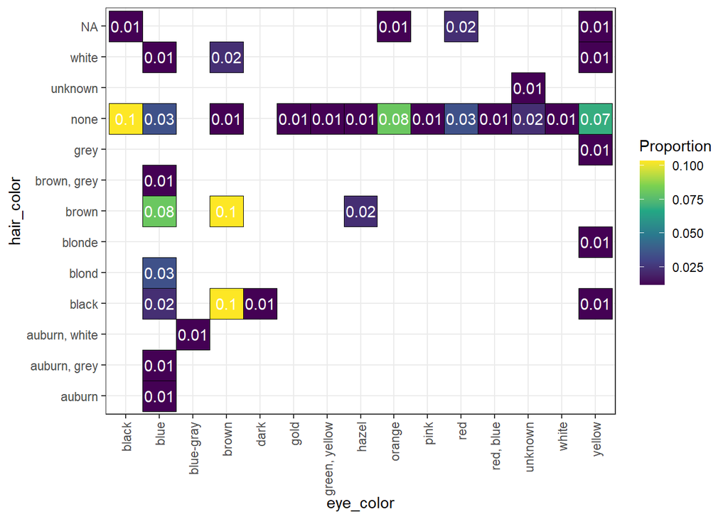

```r
starwars %>%
  count(eye_color, hair_color) %>%
  mutate(proportion_obs = n / sum(n)) %>%
  ggplot(mapping = aes(x = eye_color, y = hair_color)) +
  geom_tile(mapping = aes(fill = proportion_obs), color = "black") +
  geom_text(mapping = aes(label = signif(proportion_obs, 1)), color = "white") +
  scale_fill_viridis_c("Proportion") +
  theme_bw() +
  theme(axis.text.x = element_text(angle=90, hjust = 1, vjust = 0.5))
```

## Grouping and summarizing

The `count()` function is useful but it is clearly limited since it can only count the number of observations. However, that limitation was made on purpose. When we need greater flexibility and greater control we can use the combination of `group_by()` and `summarize()`. The `group_by()` function works behind the scenes to put “meta” information associated with the data set. Let’s see what happens when we use the `group_by()` function to group by the `eye_color` and `hair_color` on the `starwars` data set. To make the print out easier to read, the result of `group_by()` is pipped into `glimpse()`.

```r
starwars %>%
  group_by(eye_color, hair_color) %>%
  glimpse()
```

```
## Rows: 87
## Columns: 14
## Groups: eye_color, hair_color [35]
## $ name       <chr> "Luke Skywalker", "C-3PO", "R2-D2", "Darth Vader", "Leia Or…
## $ height     <int> 172, 167, 96, 202, 150, 178, 165, 97, 183, 182, 188, 180, 2…
## $ mass       <dbl> 77.0, 75.0, 32.0, 136.0, 49.0, 120.0, 75.0, 32.0, 84.0, 77.…
## $ hair_color <chr> "blond", NA, NA, "none", "brown", "brown, grey", "brown", N…
## $ skin_color <chr> "fair", "gold", "white, blue", "white", "light", "light", "…
## $ eye_color  <chr> "blue", "yellow", "red", "yellow", "brown", "blue", "blue",…
## $ birth_year <dbl> 19.0, 112.0, 33.0, 41.9, 19.0, 52.0, 47.0, NA, 24.0, 57.0, …
## $ sex        <chr> "male", "none", "none", "male", "female", "male", "female",…
## $ gender     <chr> "masculine", "masculine", "masculine", "masculine", "femini…
## $ homeworld  <chr> "Tatooine", "Tatooine", "Naboo", "Tatooine", "Alderaan", "T…
## $ species    <chr> "Human", "Droid", "Droid", "Human", "Human", "Human", "Huma…
## $ films      <list> <"The Empire Strikes Back", "Revenge of the Sith", "Return…
## $ vehicles   <list> <"Snowspeeder", "Imperial Speeder Bike">, <>, <>, <>, "Imp…
## $ starships  <list> <"X-wing", "Imperial shuttle">, <>, <>, "TIE Advanced x1",…
```

The displayed result is the exact same as we saw before, **except** we see that `glimpse()` displays the grouping information. It tells us that groups are specified by `eye_color` and `hair_color` and that there are 35 groups.

We cannot “see” those groups in the observations, because we have not performed operations with the groups. A common sequence of operations is to follow `group_by()` with the `summarize()` function. As the name states, `summarize()` summarizes a data set. The sequence of `group_by()` and `summarize()` “reads” as summarize the data associated with groups defined by the variables in the `group_by()` function. This sequence of steps is usually referred to as **split-apply-combine** in that we:  
* “split” or “divide” the data set into different groups. * “apply” functions and operations to each group. * “combine” the groups back into a single data set.

The `group_by()` and `summarize()` sequence performs the “split-apply-combine” work flow for us. We do not need to manually divide the data into separate groups. Everything takes place behind the scenes.

Let’s see how this works by counting the number of observations associated with each combination of `eye_color` and `hair_color` in the `starwars` data set. This is exactly what `count()` accomplishes, so it will be a useful confirmation that we are performing the steps correctly. The `summarize()` function will create new columns in a grouped data set. The rows will correspond to the unique combinations of the variables specified within `group_by()`. The operations we specify in `summarize()` will be performed on each unique combination using syntax similar to that of the `mutate()` function. We create a new summarized variable with the following syntax:

`<data> %>% group_by(<variables to group>) %>% summarize(<summary variable> = <operaction>)`

We will use the `n()` function to count the number of rows associated with each combination of `eye_color` and `hair_color` and create the new variable `num_rows`. The code chunk below shows the steps to perform the grouping and counting. The result is piped into the `arrange()` function to arrange by descending order of `num_rows`. The result should be consistent with what we saw before, except for we are using `num_rows` instead of the variable `n`.

```r
starwars %>%
  group_by(eye_color, hair_color) %>%
  summarise(num_rows = n()) %>%
  arrange(desc(num_rows))
```

```
## # A tibble: 35 × 3
## # Groups:   eye_color [15]
##    eye_color hair_color num_rows
##    <chr>     <chr>         <int>
##  1 black     none              9
##  2 brown     black             9
##  3 brown     brown             9
##  4 blue      brown             7
##  5 orange    none              7
##  6 yellow    none              6
##  7 blue      blond             3
##  8 blue      none              3
##  9 red       none              3
## 10 blue      black             2
## # … with 25 more rows
```

When grouping by multiple variables, a warning message is automatically returned stating that a grouping structure is still present. By default, the `summarize()` function removes one “grouping layer”. The grouping layers are ordered in the same order the grouping variables were typed. Thus, `hair_color` was removed and the summarized data are still grouped by the `eye_color` variable.

Personally, I do not like to work with grouped objects. Instead, I like the returned summarized object to be a “regular” dataframe or tibble and thus have no grouping structure imposed. There are two ways we can remove the grouping structure. First, we can pass the returned grouped object to the `ungroup()` function to remove any grouping structure:

```r
starwars %>%
  group_by(eye_color, hair_color) %>%
  summarise(num_rows = n()) %>%
  ungroup() %>%
  arrange(desc(num_rows))
```

```
## # A tibble: 35 × 3
##    eye_color hair_color num_rows
##    <chr>     <chr>         <int>
##  1 black     none              9
##  2 brown     black             9
##  3 brown     brown             9
##  4 blue      brown             7
##  5 orange    none              7
##  6 yellow    none              6
##  7 blue      blond             3
##  8 blue      none              3
##  9 red       none              3
## 10 blue      black             2
## # … with 25 more rows
```

```r
starwars %>%
  group_by(eye_color, hair_color) %>%
  summarise(num_rows = n(),
            .groups = 'drop') %>%
  arrange(desc(num_rows))
```

```
## # A tibble: 35 × 3
##    eye_color hair_color num_rows
##    <chr>     <chr>         <int>
##  1 black     none              9
##  2 brown     black             9
##  3 brown     brown             9
##  4 blue      brown             7
##  5 orange    none              7
##  6 yellow    none              6
##  7 blue      blond             3
##  8 blue      none              3
##  9 red       none              3
## 10 blue      black             2
## # … with 25 more rows
```

Let’s now see more complex operations. Perhaps we would like to calculate the number of unique `homeworld`s associated with each `eye_color` and `hair_color` combinations. The `n_distinct()` function accepts a variable as an argument and counts the number of unique values. It does **not** return what those values are, just the number of unique values. We will assign the result of the `n_distinct()` function to `num_home_worlds` within the `summarize()` call. The result is then piped to `arrange()` to again arrange by the number of rows associated with each `eye_color` and `hair_color` combination.

```r
starwars %>%
  group_by(eye_color, hair_color) %>%
  summarise(num_rows = n(),
            num_home_worlds = n_distinct(homeworld),
            .groups = 'drop') %>%
  arrange(desc(num_rows))
```

```
## # A tibble: 35 × 4
##    eye_color hair_color num_rows num_home_worlds
##    <chr>     <chr>         <int>           <int>
##  1 black     none              9               8
##  2 brown     black             9               7
##  3 brown     brown             9               5
##  4 blue      brown             7               5
##  5 orange    none              7               5
##  6 yellow    none              6               6
##  7 blue      blond             3               2
##  8 blue      none              3               3
##  9 red       none              3               3
## 10 blue      black             2               1
## # … with 25 more rows
```

Notice that now our summarized data set has an additional column, `num_home_worlds`. Let’s confirm that the `eye_color=='black'` and `hair_color=='none'` combination has 8 unique homeworlds. The code chunk below uses `filter()` and `count()` to count the number of homeworlds associated associated with the that specific combination of `eye_color` and `hair_color`. The result is pipped into `nrows()` which shows that there are exactly 8 values of `homeworld`.

```r
starwars %>%
  filter(eye_color == "black", hair_color == "none") %>%
  count(homeworld) %>%
  nrow()
```

```
## [1] 8
```

Let’s now include the number of unique `species` types each `eye_color` and `hair_color` combination correspond to. The code chunk below creates a third variable within `summarize()` using the `n_distinct()` function, but this time applied to `species` rather than `homeworld`. The result is assigned to the `num_species` variable. Please note that we are “assigning” the result to a variable with `=` **not** the assignment operator, `<-`, because the variable is being created within a data.frame (tibble) object.

```r
starwars %>%
  group_by(eye_color, hair_color) %>%
  summarise(num_rows = n(),
            num_home_worlds = n_distinct(homeworld),
            num_species = n_distinct(species),
            .groups = 'drop') %>%
  arrange(desc(num_rows))
```

```
## # A tibble: 35 × 5
##    eye_color hair_color num_rows num_home_worlds num_species
##    <chr>     <chr>         <int>           <int>       <int>
##  1 black     none              9               8           8
##  2 brown     black             9               7           3
##  3 brown     brown             9               5           2
##  4 blue      brown             7               5           3
##  5 orange    none              7               5           5
##  6 yellow    none              6               6           6
##  7 blue      blond             3               2           1
##  8 blue      none              3               3           3
##  9 red       none              3               3           3
## 10 blue      black             2               1           1
## # … with 25 more rows
```

We can continue to chain together operations within our workflow. For example let’s use `count()` to see the number of `eye_color` and `hair_color` combinations associated with each unique value `num_species`. This does not correspond to the `eye_color` and `hair_color` combinations per `species`. It is the number of times the unique values of `num_species` are present in the result above. Notice in the code chunk below the `ungroup()` function is used after `summarise()` and before `count()`. The `ungroup()` function removes all grouping structure. I like to use to return to a “simpler” tibble (a data object) when I want to perform additional operations.

```r
starwars %>%
  group_by(eye_color, hair_color) %>%
  summarise(num_rows = n(),
            num_home_worlds = n_distinct(homeworld),
            num_species = n_distinct(species),
            .groups = 'drop') %>%
  ungroup() %>%
  count(num_species) %>%
  arrange(desc(n))
```

```
## # A tibble: 6 × 2
##   num_species     n
##         <int> <int>
## 1           1    25
## 2           3     4
## 3           2     3
## 4           5     1
## 5           6     1
## 6           8     1
```

## Homeworlds and eye color

We have been looking through basic counts of the variables in the `starwars` data set. Let’s now see if the `eye_color` is associated with a few `homeworld`s. The code chunk below displays the numbe rof rows associated with each `homeworld`. The two `homeworld`s with the highest counts are `'Naboo'` and `'Tatooine'`. If you know anything about the Original Trilogy (OT), then you should know about Tatooine. The planet Naboo was introduced in the Prequel Trilogy (PT).

```r
starwars %>% count(homeworld) %>% arrange(desc(n))
```

```
## # A tibble: 49 × 2
##    homeworld     n
##    <chr>     <int>
##  1 Naboo        11
##  2 Tatooine     10
##  3 <NA>         10
##  4 Alderaan      3
##  5 Coruscant     3
##  6 Kamino        3
##  7 Corellia      2
##  8 Kashyyyk      2
##  9 Mirial        2
## 10 Ryloth        2
## # … with 39 more rows
```

Earlier in this report we saw that the `brown` eye color was the most common in the data set. So let’s see if having brown eyes is associated with being from either Tatooine or Naboo. The code chunk below performs a series of steps and assigns the result to the tibble, `my_df`. The first step is to select `eye_color` and `homeworld` using `dplyr::select()` from `starwars`. This way we can work with a smaller data set. The result is piped into `mutate()` where a new column `obs_planets` is created based on if `homeworld` is either `'Tatooine'` or `'Naboo'`. The values are set to either `"yes"` or `"no"` using the `ifelse()` function. A second new column is also created, `pred_planets` which has values `"yes"` or `"no"` based on if `eye_color` equals `'brown'` or not. The `pred_planets` values are created using an `ifelse()` function.

```r
my_df <- starwars %>%
  select(eye_color, homeworld) %>%
  mutate(obs_planets = ifelse(homeworld %in% c("Tatooine", "Naboo"),
                              "yes",
                              "no"),
         pred_planets = ifelse(eye_color %in% c("brown"),
                               "yes",
                               "no"))
```

Let’s now check how well my guess turned out to be. There are multiple ways we can do this. One approach is to pipe `my_df` into `summarise()` directly. We can now specify summary actions we wish to perform on the entire data set. The code chunk below uses the `mean()` function calculate the fraction of rows in `my_df` where `pred_planets` is equal to `obs_planets`.

```r
my_df %>%
  summarise(mean(pred_planets == obs_planets))
```

```
## # A tibble: 1 × 1
##   `mean(pred_planets == obs_planets)`
##                                 <dbl>
## 1                               0.678
```

My guess about if `'brown'` eyes are associated with `"Tatooine"` and/or `"Naboo"` has an accuracy of about 68%. But how well does that compare to the empirical fraction of those planets in the data set? Let’s calculate the fraction of rows where `obs_planets` equals `'yes'` using the `mean()` function in the code chunk below.

```r
mean(my_df$obs_planets == "yes")
```

```
## [1] 0.2413793
```

Wow only 24% of the observations are from those two planets! So it looks like knowing if the character has `'brown'` eyes helps us make a better guess as to whether they are from Naboo or Tatooine!

However, what if my “model” only appears to do well because 75% of the observations are **not** from those two planets? After all, the Accuracy does not care how the “prediction” was correct, just as long as it was correct. The confusion matrix will help us understand the error behavior.

The code chunk below uses the `count()` function to count the number of rows associated with the combinations of the `pred_planets` and `obs_planets` variables. The result is saved to the variable `my_confusion`.

```r
my_confusion <- my_df %>%
  count(pred_planets, obs_planets)
```

The code chunk below prints out the `my_confusion` object. We can see that there are 4 rows. The first row corresponds to the “predicted classification” being `'no'` **and** the observed “class” is also `'no'`. The last row is the “predicted classification” being `'yes'` **and** the observed “class” is also `'yes'`.

```r
my_confusion
```

```
## # A tibble: 4 × 3
##   pred_planets obs_planets     n
##   <chr>        <chr>       <int>
## 1 no           no             52
## 2 no           yes            14
## 3 yes          no             14
## 4 yes          yes             7
```

So how correct was my classification when the observed planets were Naboo and Tatooine? The code chunk below uses `filter()` to focus just on `obs_class == 'yes'` and then pipes the result into `mutate()` to calculate the proportion or fraction of observations that were correctly classified. Notice the code chunk below uses the same setup as earlier in the report to calculate the proportion before making the heat map. The proportion is assigned to the variable `prop_val` within `mutate()`. As we can see in the print out below, my “model” is correct just 1/3 of time when the homeworld is Naboo or Tatooine. So it does not really seem like my model is all that great…

```r
my_confusion %>%
  filter(obs_planets == "yes") %>%
  mutate(prop_val = n / sum(n))
```

```
## # A tibble: 2 × 4
##   pred_planets obs_planets     n prop_val
##   <chr>        <chr>       <int>    <dbl>
## 1 no           yes            14    0.667
## 2 yes          yes             7    0.333
```

We can then extract the proportion of correct classifications when `obs_planets == 'yes'` through another `filter()` call and then the `pull()` function. `pull()` “pulls” or extracts a column from a data.frame or tibble into a “regular” vector. The result is assigned to the variable `tpr_planets`.

```r
tpr_planets <- my_confusion %>%
  filter(obs_planets == "yes") %>%
  mutate(prop_val = n / sum(n)) %>%
  filter(pred_planets == obs_planets) %>%
  pull(prop_val)
```

Let’s now consider the behavior when `obs_planets == 'no'`. The steps are similar to what we saw before. We first use the `filter()` function to focus on the rows from `my_confusion` where `obs_planets == 'no'`. The `mutate()` function is again called to calculate the proportion or fraction of rows associated with the remaining combinations of `pred_planets` and `obs_planets`. As we see below when `obs_planets == 'no'`, my “model” is correct about 79% of the time. That sounds ok, but remember we already saw 75% of the observations in the data set are `obs_planets == 'no'`. So it seems like it’s just pretty easy to say the `homeworld` is not Naboo or Tatooine. Maybe my model is not that great after all…

```r
my_confusion %>%
  filter(obs_planets == "no") %>%
  mutate(prop_val = n / sum(n))
```

```
## # A tibble: 2 × 4
##   pred_planets obs_planets     n prop_val
##   <chr>        <chr>       <int>    <dbl>
## 1 no           no             52    0.788
## 2 yes          no             14    0.212
```